# Apple Ventas

Adrián González Retamosa

11/16/2020

# OBJETIVOS

Estudiar el comportamiento estacionario de la serie, estimar modelos ETS y ARIMA para comprobar cual de los dos presenta menores errores de predicción.

# Esquema

1. Presentación de la serie de ingresos trimestrales de Apple.
2. Modelo ETS.
3. Modelo ARIMA.
4. Comparación y conclusiones.

## 1. Presentación de la serie de ingresos trimestrales de Apple.

```r
library(readr)
library(forecast)
library(xts)
library(ggplot2)
library(ggfortify)
library(tidyverse)
```

```r
setwd("/Users/adrian_gr/desktop")
df_a <- read.csv('IngresosApple.csv', sep = ';', dec = ',')
```

Antes de convertir el dataframe en una serie temporal tomamos el log de los Ingresos que será con lo que trabajaremos.

```r
#ponemos los ingresos en terminos log
df_a <- df_a %>%
  mutate(Ingresos = log(Ingresos))
```

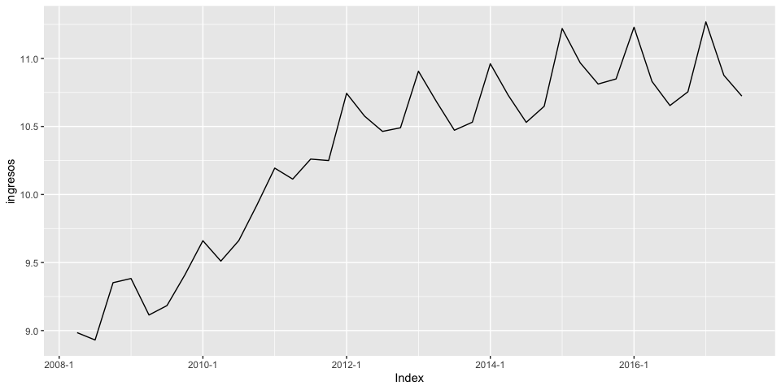

```r
#creamos una seq con las fechas correspondientes
date <- seq(as.Date("2008-06-30"), as.Date("2017-09-30"), by = "quarter")

#la añadamimos a nuestro dataset para luego utilizarlo en la construccion de la serie temporal
df_a <- df_a %>%
  mutate(fecha = date)

#creamos la serie temporal de los ingresos de apple
ingresos <- xts(df_a$Ingresos, order.by = as.Date(df_a$fecha, '%Y/%m/%d'), frequency=4)

#lo convertimos a trimestral por si tuviesemos problemas
ingresos_q <- to.quarterly(ingresos)
ingresos_q <- as.zoo(ingresos_q$ingresos.Open)
names(ingresos_q) <- 'ingresos'

#graficamos
autoplot(ingresos_q)
```

Vemos que no es estacionaria Tambien podemos intuir un modelo aditivo en el componente tendencial y multiplicativo en el estacional.

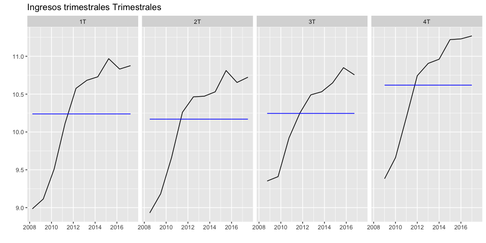

```r
tsIngresos=ts(coredata(ingresos), start = c(2008, 2), frequency = 4)
ggfreqplot(tsIngresos, freq=4, nrow=1, facet.labeller=c("1T","2T","3T","4T")) +
ggtitle("Ingresos trimestrales Trimestrales")
```

Como era de esperar los ingresos medios de apple aumentan en el último cuatrimestre ya que es el periodo en el cual se anuncian la mayoría de nuevos productos.

El objetivo es predecir los ingresos para los trimestres de 2017, para ello vamos a eliminar estos datos de la serie para poder predecir sobre ellos.

```r
n_fore <- 3
obs <- length(ingresos_q)
ingresos_train <- window(ingresos_q,
                        start = index(ingresos_q[1]),
                        end = index(ingresos_q[obs - n_fore]))
```

## 2. Modelo ETS.

Generamos un modelo ETS de forma automatica que nos indicara las estructura de los componentes estacionales, tendenciales y del error.

```r
# eleccion del modelo ETS por cross validation
m_ets <- ets(ingresos_train)

#Analizamos el modelo obtenido y las predicciones
fore_ets <- forecast(m_ets)
summary(fore_ets)
```

```
##
## Forecast method: ETS(M,A,A)
##
## Model Information:
## ETS(M,A,A)
##
## Call:
##  ets(y = ingresos_train)
##
##   Smoothing parameters:
##     alpha = 0.4924
##     beta  = 0.3676
##     gamma = 0.5076
##
##   Initial states:
##     l = 9.0376
##     b = 0.0906
##     s = 0.1881 0.0807 -0.2048 -0.064
##
##   sigma:  0.0117
##
##         AIC        AICc         BIC
## -14.9459243  -7.7459243  -0.9477917
##
## Error measures:
##                        ME      RMSE        MAE         MPE      MAPE      MASE
## Training set -0.006606452 0.1059325 0.08553984 -0.06269475 0.8397395 0.3489455
##                     ACF1
## Training set 0.007074111
##
## Forecasts:
##         Point Forecast     Lo 80    Hi 80     Lo 95    Hi 95
## 2017 Q1       11.11778 10.950534 11.28502 10.862000 11.37356
## 2017 Q2       10.82187 10.604626 11.03912 10.489623 11.15412
## 2017 Q3       10.69711 10.401017 10.99319 10.244277 11.14993
## 2017 Q4       10.77713 10.381404 11.17286 10.171919 11.38234
## 2018 Q1       11.14016 10.570250 11.71007 10.268556 12.01177
## 2018 Q2       10.84425 10.161066 11.52744  9.799408 11.88910
## 2018 Q3       10.71949  9.906558 11.53242  9.476220 11.96276
## 2018 Q4       10.79951  9.843115 11.75591  9.336827 12.26220
```

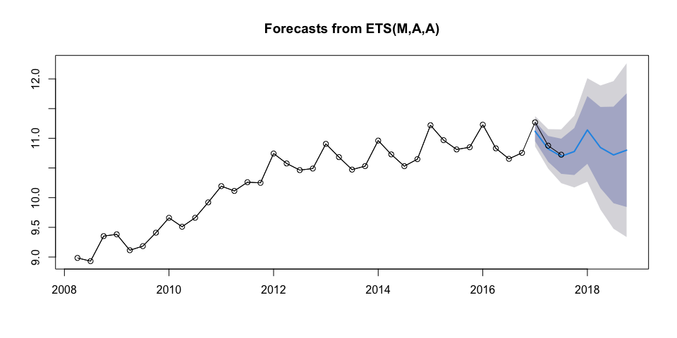

```r
#Grafico de prediccion modelo ETS
plot(fore_ets)
lines(window(ingresos_q),type="o")
```

A continuación mostramos una tabla con los errores de predicción del modelo ETS, que utilizamos para compararlo con el modelo ARIMA

```r
#obtenemos los diferentes tipos de errores de prediccion
ajuste_ets<-ets(window(tsIngresos, end=2016+3/4))
fingreos_ets=forecast(ajuste_ets, h= n_fore)

error_pre_ets <- forecast:::testaccuracy(fingreos_ets$mean, window(tsIngresos,start=2017),test = NULL, d = NULL, D = NULL)

error_pre_ets <- as.data.frame(error_pre_ets)

knitr::kable(error_pre_ets)
```

|  | error_pre_ets |
| --- | --- |
| ME | 0.0772417 |
| RMSE | 0.0939617 |
| MAE | 0.0772417 |
| MPE | 0.6951939 |
| MAPE | 0.6951939 |
| ACF1 | -0.0617592 |
| Theil’s U | 0.1433107 |

## 3. Modelo ARIMA.

Observamos el modelo SARIMA mas simple posible, ya que no tiene autoregresivo ni media movil en la parte regular ni estacional, solo hemos tomado una diferencia en cada una de las partes.

```r
m_arima <- auto.arima(ingresos_train, lambda = 0)
summary(m_arima)
```

```
## Series: ingresos_train
## ARIMA(0,1,0)(0,1,0)[4]
## Box Cox transformation: lambda= 0
##
## sigma^2 estimated as 0.0001455:  log likelihood=90.04
## AIC=-178.08   AICc=-177.94   BIC=-176.68
##
## Training set error measures:
##                        ME      RMSE        MAE         MPE      MAPE      MASE
## Training set -0.009433358 0.1149941 0.08310241 -0.08075189 0.8077781 0.3390024
##                    ACF1
## Training set -0.1045467
```

Con el contraste de JUNG-BOX comprobamos que no existe autocorrelación entre los residuos del modelo ya que obtenemos un p-valor superior al 5%, por lo que no rechazamos la Ho. También comprobamos que los residuos son un ruido blanco, media 0 y varianza constante, a traves del correlograma.

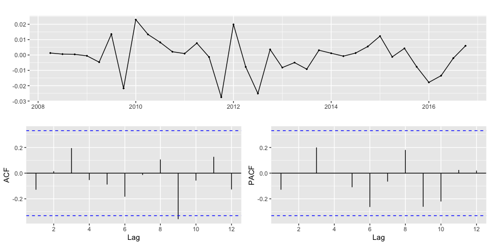

```r
ggtsdisplay(m_arima$residuals)
```

```r
Box.test(m_arima$residuals,lag=12, fitdf=2, type="Lj")
```

```
##
##  Box-Ljung test
##
## data:  m_arima$residuals
## X-squared = 13.052, df = 10, p-value = 0.2208
```

Representamos las predicciones de nuestro modelo hasta finales de 2018, junto a la serie real.

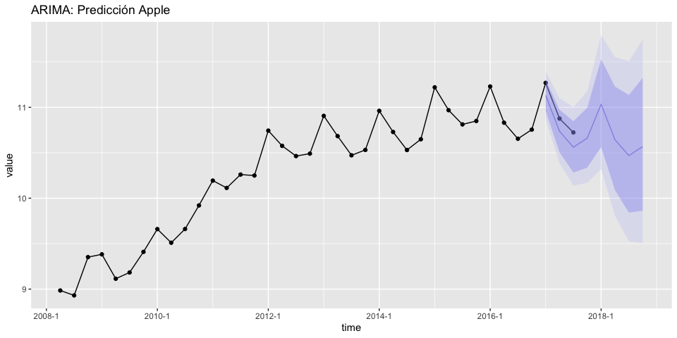

```r
df_real <- data.frame(value = as.vector(ingresos_q),
                     time = time(ingresos_q)) #df con los valores reales

fingresos_arima <- forecast(m_arima)

ggplot(df_real) +
  geom_point(aes(x=time,y=value)) + # hacemos el grafico con los valores de las serie,  hasta el 3 trimeste de 2017
  geom_line(aes(x=time,y=value)) +
  geom_forecast(fingresos_arima,alpha=0.3) +
  ggtitle("ARIMA: Predicción Apple")
```

## 4. Comparación y conclusiones.

```r
error_pre_arima <- c(-0.009433358, 0.1149941, 0.08310241, -0.08075189, 0.8077781, 0.3390024, -0.1045467)

error_pre <- data.frame( ETS = error_pre_ets$error_pre_ets,
                        ARIMA = error_pre_arima,
                        row.names = c('ME', 'RMSE', 'MAE', 'MPE', 'MAPE', 'MASE', 'ACF1'))

COMPARACIÓN <- ifelse((error_pre$ETS - error_pre$ARIMA < 0), 'ETS', 'ARIMA')
error_pre1 <- cbind(error_pre, COMPARACIÓN)

knitr::kable(error_pre1)
```

[output not shown]

En el siguiente gráfico representamos juntas las predicciones del modelo ETS(azul) y del ARIMA(rojo) y observamos que el modelo ARIMA es un poco mas bajista.

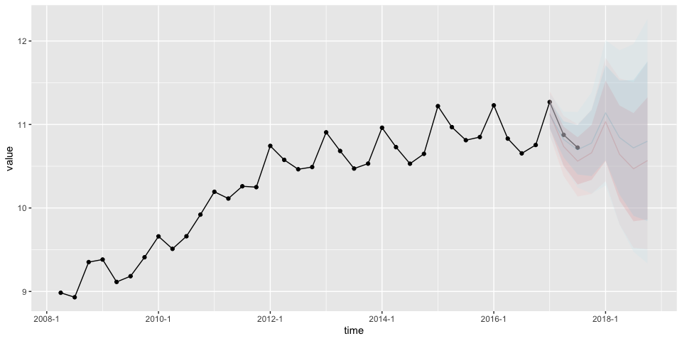

```r
ggplot(df_real) +
  geom_point(aes(x=time,y=value)) +
  geom_line(aes(x=time,y=value)) +
  geom_forecast(fingresos_arima,alpha=0.2, show.legend = T, col = 'red') +
  geom_forecast(fore_ets,alpha=0.2, show.legend = T, col ='skyblue')
```

```r
  ggtitle("ARIMA: Predicción Apple")
```

```
## $title
## [1] "ARIMA: Predicción Apple"
##
## attr(,"class")
## [1] "labels"
```